# Machine Learning - Course Project

Oliver Gonzalez

November 18, 2017

## Background

Using devices such as Jawbone Up, Nike FuelBand, and Fitbit it is now possible to collect a large amount of data about personal activity relatively inexpensively. These type of devices are part of the quantified self movement â a group of enthusiasts who take measurements about themselves regularly to improve their health, to find patterns in their behavior, or because they are tech geeks. One thing that people regularly do is quantify how much of a particular activity they do, but they rarely quantify how well they do it. In this project, your goal will be to use data from accelerometers on the belt, forearm, arm, and dumbell of 6 participants. They were asked to perform barbell lifts correctly and incorrectly in 5 different ways. More information is available from the website here: http://groupware.les.inf.puc-rio.br/har (see the section on the Weight Lifting Exercise Dataset).

## Data Processing and Data cleaning

The data for this project come from this source: http://groupware.les.inf.puc-rio.br/har. If you use the document you create for this class for any purpose please cite them as they have been very generous in allowing their data to be used for this kind of assignment.

The training data for this project are available here: https://d396qusza40orc.cloudfront.net/predmachlearn/pml-training.csv The test data are available here: https://d396qusza40orc.cloudfront.net/predmachlearn/pml-testing.csv. We must Download and clean de data from division errors and empty strings replacing them by NA values.

## Cross Validation & Data Partitioning

Now lets partition de data into a trainning (60%) and test (40%) sets. Also lets remove any NA and DIV/0 values.

```r
train_url <- "http://d396qusza40orc.cloudfront.net/predmachlearn/pml-training.csv"
test_url <- "http://d396qusza40orc.cloudfront.net/predmachlearn/pml-testing.csv"
training_set<- read.csv(url(train_url), na.strings=c("NA","#DIV/0!",""))
testing_set <- read.csv(url(test_url), na.strings=c("NA","#DIV/0!",""))
inTrain <- createDataPartition(y=training_set$classe, p=0.60, list=FALSE)
myTraining <- training_set[inTrain, ]; myTesting <- training_set[-inTrain, ]
dim(myTraining); dim(myTesting)
```

```
## [1] 11776   160
```

```
## [1] 7846  160
```

```r
removeNAcols   <- function(x) { x[ , colSums( is.na(x) ) < nrow(x) ] }
myTraining <- removeNAcols(myTraining)
myTesting  <- removeNAcols(myTesting)

complete   <- function(x) {x[,sapply(x, function(y) !any(is.na(y)))] }
incomplete <- function(x) {names( x[,sapply(x, function(y) any(is.na(y)))] ) }

trtr.na.var    <- incomplete(myTraining)
trts.na.var    <- incomplete(myTesting)
myTraining <- complete(myTraining)
myTesting  <- complete(myTesting)

#Lets remove the columns that are not predictors
myTraining_fset <- myTraining[,8:length(myTraining)]

#lets clear the variables with near zero variance
vNearZero <- nearZeroVar(myTraining_fset, saveMetrics = TRUE)
#Checking the result to see that there are zero values left
vNearZero
```

```
##                      freqRatio percentUnique zeroVar   nzv
## roll_belt             1.110906    8.61922554   FALSE FALSE
## pitch_belt            1.180952   13.64639946   FALSE FALSE
## yaw_belt              1.126667   14.35122283   FALSE FALSE
## total_accel_belt      1.091022    0.23777174   FALSE FALSE
## gyros_belt_x          1.065534    1.07846467   FALSE FALSE
## gyros_belt_y          1.186564    0.54347826   FALSE FALSE
## gyros_belt_z          1.088372    1.34171196   FALSE FALSE
## accel_belt_x          1.031780    1.31623641   FALSE FALSE
## accel_belt_y          1.129630    1.13790761   FALSE FALSE
## accel_belt_z          1.107422    2.42866848   FALSE FALSE
## magnet_belt_x         1.070755    2.42866848   FALSE FALSE
## magnet_belt_y         1.028351    2.34375000   FALSE FALSE
## magnet_belt_z         1.041379    3.54110054   FALSE FALSE
## roll_arm             48.309524   19.49728261   FALSE FALSE
## pitch_arm            88.217391   22.29110054   FALSE FALSE
## yaw_arm              30.742424   21.50135870   FALSE FALSE
## total_accel_arm       1.038961    0.56046196   FALSE FALSE
## gyros_arm_x           1.084175    5.31589674   FALSE FALSE
## gyros_arm_y           1.548173    3.14198370   FALSE FALSE
## gyros_arm_z           1.163399    1.95312500   FALSE FALSE
## accel_arm_x           1.093750    6.41134511   FALSE FALSE
## accel_arm_y           1.099237    4.39877717   FALSE FALSE
## accel_arm_z           1.166667    6.38586957   FALSE FALSE
## magnet_arm_x          1.018868   11.09035326   FALSE FALSE
## magnet_arm_y          1.000000    7.20957880   FALSE FALSE
## magnet_arm_z          1.030769   10.62330163   FALSE FALSE
## roll_dumbbell         1.049383   87.44904891   FALSE FALSE
## pitch_dumbbell        2.129412   85.33457880   FALSE FALSE
## yaw_dumbbell          1.231884   86.72724185   FALSE FALSE
 ## total_accel_dumbbell  1.100119    0.35665761   FALSE FALSE
## gyros_dumbbell_x      1.013333    1.95312500   FALSE FALSE
## gyros_dumbbell_y      1.169863    2.24184783   FALSE FALSE
## gyros_dumbbell_z      1.048518    1.63892663   FALSE FALSE
## accel_dumbbell_x      1.038835    3.33729620   FALSE FALSE
## accel_dumbbell_y      1.134752    3.80434783   FALSE FALSE
## accel_dumbbell_z      1.362963    3.37975543   FALSE FALSE
## magnet_dumbbell_x     1.027523    8.78057065   FALSE FALSE
## magnet_dumbbell_y     1.240385    6.87839674   FALSE FALSE
## magnet_dumbbell_z     1.050847    5.58763587   FALSE FALSE
## roll_forearm         12.261780   14.69938859   FALSE FALSE
## pitch_forearm        63.270270   20.74558424   FALSE FALSE
## yaw_forearm          16.137931   14.11345109   FALSE FALSE
## total_accel_forearm   1.132877    0.57744565   FALSE FALSE
## gyros_forearm_x       1.048632    2.38620924   FALSE FALSE
## gyros_forearm_y       1.043103    6.02921196   FALSE FALSE
## gyros_forearm_z       1.080808    2.37771739   FALSE FALSE
## accel_forearm_x       1.185185    6.55570652   FALSE FALSE
## accel_forearm_y       1.033333    8.19463315   FALSE FALSE
## accel_forearm_z       1.031915    4.63654891   FALSE FALSE
## magnet_forearm_x      1.130435   12.16032609   FALSE FALSE
## magnet_forearm_y      1.215686   15.26834239   FALSE FALSE
## magnet_forearm_z      1.027778   13.45108696   FALSE FALSE
## classe                1.469065    0.04245924   FALSE FALSE
```

## Model Selection

The selected model for this task will be Random Forest because it generates an internal unbiased estimate of the generalization error as the forest building progresses, Random Forest works well with a mixture of numerical and categorical features

```r
#The model chosen is the random forest method
keep <- names(myTraining_fset)
#fit model- RANDOM FOREST
set.seed(1235)

modFit <- randomForest(classe~., data = myTraining_fset)
print(modFit)
```

```
##
## Call:
##  randomForest(formula = classe ~ ., data = myTraining_fset)
##                Type of random forest: classification
##                      Number of trees: 500
## No. of variables tried at each split: 7
##
##         OOB estimate of  error rate: 0.65%
## Confusion matrix:
##      A    B    C    D    E class.error
## A 3343    4    0    0    1 0.001493429
## B   14 2256    9    0    0 0.010092146
## C    0   13 2039    2    0 0.007302824
## D    0    0   24 1905    1 0.012953368
## E    0    0    2    7 2156 0.004157044
```

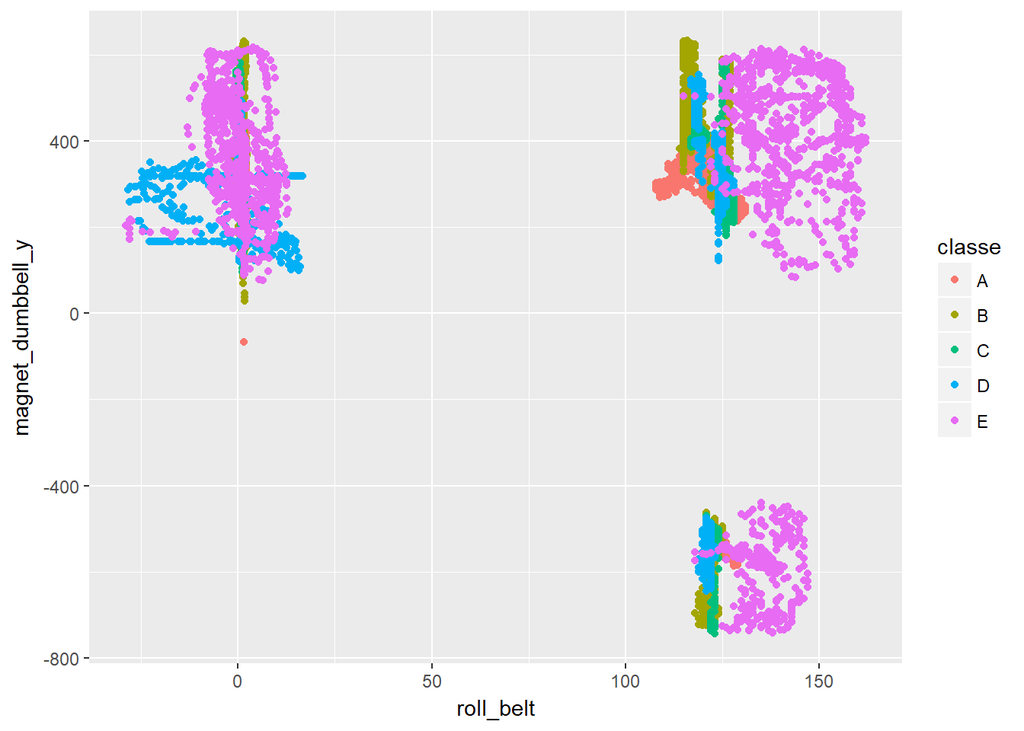

```r
qplot(roll_belt, magnet_dumbbell_y, colour=classe, data=myTraining_fset)
```

```r
predict1 <- predict(modFit, myTesting, type = "class")
confusionMatrix(myTesting$classe, predict1)
```

```
## Confusion Matrix and Statistics
##
##           Reference
## Prediction    A    B    C    D    E
##          A 2222    8    0    0    2
##          B    9 1505    4    0    0
##          C    0   17 1344    7    0
##          D    0    0   20 1262    4
##          E    0    0    0    5 1437
##
## Overall Statistics
##
##                Accuracy : 0.9903
##                  95% CI : (0.9879, 0.9924)
##     No Information Rate : 0.2843
##     P-Value [Acc > NIR] : < 2.2e-16
##
##                   Kappa : 0.9877
##  Mcnemar's Test P-Value : NA
##
## Statistics by Class:
##
##                      Class: A Class: B Class: C Class: D Class: E
## Sensitivity            0.9960   0.9837   0.9825   0.9906   0.9958
## Specificity            0.9982   0.9979   0.9963   0.9963   0.9992
## Pos Pred Value         0.9955   0.9914   0.9825   0.9813   0.9965
## Neg Pred Value         0.9984   0.9960   0.9963   0.9982   0.9991
## Prevalence             0.2843   0.1950   0.1744   0.1624   0.1839
## Detection Rate         0.2832   0.1918   0.1713   0.1608   0.1832
## Detection Prevalence   0.2845   0.1935   0.1744   0.1639   0.1838
## Balanced Accuracy      0.9971   0.9908   0.9894   0.9935   0.9975
```

```r
predict_trainingset <- predict(modFit, myTraining, type = "class")
confusionMatrix(myTraining$classe, predict_trainingset)
```

```
## Confusion Matrix and Statistics
##
##           Reference
## Prediction    A    B    C    D    E
##          A 3348    0    0    0    0
##          B    0 2279    0    0    0
##          C    0    0 2054    0    0
##          D    0    0    0 1930    0
##          E    0    0    0    0 2165
##
## Overall Statistics
##
##                Accuracy : 1
##                  95% CI : (0.9997, 1)
##     No Information Rate : 0.2843
##     P-Value [Acc > NIR] : < 2.2e-16
##
##                   Kappa : 1
##  Mcnemar's Test P-Value : NA
##
## Statistics by Class:
##
##                      Class: A Class: B Class: C Class: D Class: E
## Sensitivity            1.0000   1.0000   1.0000   1.0000   1.0000
## Specificity            1.0000   1.0000   1.0000   1.0000   1.0000
## Pos Pred Value         1.0000   1.0000   1.0000   1.0000   1.0000
## Neg Pred Value         1.0000   1.0000   1.0000   1.0000   1.0000
## Prevalence             0.2843   0.1935   0.1744   0.1639   0.1838
## Detection Rate         0.2843   0.1935   0.1744   0.1639   0.1838
## Detection Prevalence   0.2843   0.1935   0.1744   0.1639   0.1838
## Balanced Accuracy      1.0000   1.0000   1.0000   1.0000   1.0000
```

## Conclusion

```r
predict_testset <- predict(modFit, testing_set, type = "class")
print(predict_testset)
```

```
##  1  2  3  4  5  6  7  8  9 10 11 12 13 14 15 16 17 18 19 20
##  B  A  B  A  A  E  D  B  A  A  B  C  B  A  E  E  A  B  B  B
## Levels: A B C D E
```